# Ординация. Многомерное шкалирование.

- Общие принципы ординации объектов
- Неметрическое многомерное шкалирование
- Как работает неметрическое многомерное шкалирование
- Оценка качества подгонки ординации
- Сравнение ординаций
- Трактовка результатов ординации

### Вы сможете

- Построить диаграмму простейшей непрямой ординации.
- Построить диаграмму nMDS.
- Охарактеризовать качество ординации с помощью величины стресса.
- Сравнить результаты нескольких ординаций

## Общие принципы ординации объектов

## Классификация методов ординации

**Ординация** (лат. *ordinatio* — расположение в порядке) — это упорядочивание объектов вдоль некоторых осей, определяющих варьирование свойств этих объектов.

| Элемент | (син)экология | морфология | молекулярная биология |
| --- | --- | --- | --- |
| Объекты | площадки / пробы | особи / клетки и т.п. | особи / клетки и т.п. |
| Собственные свойства объектов | численность / биомасса особей разных видов | измерения, свойства | интенсивность экспрессии гена/пептида |
| Внешние факторы | свойства среды | свойства среды / особей / клеток | свойства среды / особей / клеток |

Методы ординации делят на две большие группы (ter Braak, Prentice, 1988):

- Прямая ординация (*direct ordination* = *direct gradient analysis*) — когда мы проверяем, влияют ли непосредственно на свойства объектов измеренные внешние факторы.
- Непрямая ординация (*indirect ordination* = *indirect gradient analysis*) — когда мы пытаемся найти какие-то закономерности изменения свойств самих объектов, и затем пытаемся связать их с внешними факторами.

## Прямая ординация

**Прямая ординация** — упорядочивание объектов с разными свойствами вдоль осей, которые отражают значения переменных. (Например, упорядочение площадок с разным обилием видов в зависимости от параметров среды).

В самом простом случае — это ординация в осях самих внешних переменных. Но, поскольку обычно переменных больше чем 2–3, обычно пользуются осями, искуственно созданными как функции от нескольких переменных.

Синоним — ограниченная ординация (*constrained ordination*).

Методы прямой ординации позволяют тестировать гипотезы о влиянии различных внешних переменных на свойства объектов:

- анализ избыточности (*Redundancy Analysis*, RDA)
- канонический корреспондентный анализ (*Canonical Correspondence Analysis*, CCA).

## Непрямая ординация

**Непрямая ординация** — упорядочивание происходит вдоль направления изменения свойств объектов.

Используются только признаки объектов, и только затем для интерпретации результатов используется информация о значениях других переменных.

Синоним — неограниченная ординация (*unconstrained ordination*).

Методы непрямой ординации:

- неметрическое многомерное шкалирование (*non-Metric Multidimensional Scaling*, nMDS)
- анализ главных компонент (*Principal Component Analysis*, PCA)
- корреспондентный анализ (*Correspondence Analysis*, CA).

## Пример: Сообщества бентоса акватории Долгой губы (о. Б. Соловецкий, Белое море)

В этом примере используется сокращенный набор данных о бентосе Долгой губы (Нинбург, 1990; Хайтов и др., 2013) — только численность наиболее обильных видов на 68 станциях.

- `dolg_abundance.txt` — данные об обилии 25 видов
- `dolg_hydrology.txt` — данные о 4 гидрологических характеристиках: глубина, Температура придонной воды, Соленость, Степень гидратации грунта

[figure not shown]

## Читаем данные

```r
abund <- read.table("data/dolg_abundance.txt", skip = 1, header = TRUE,
    sep = ";")
hydrol <- read.table("data/dolg_hydrology.txt", skip = 1, header = TRUE,
    sep = ";")
```

## Задание: Прямая ординация станций в осях Температуры и Солености

Постройте диаграмму, отражающую ординацию станций в осях Температуры и Солености.

Модифицируйте график так, чтобы была еще видна связь с суммарным обилием видов в пробах.

## Прямая ординация станций в осях Температуры и Солености

### Решение

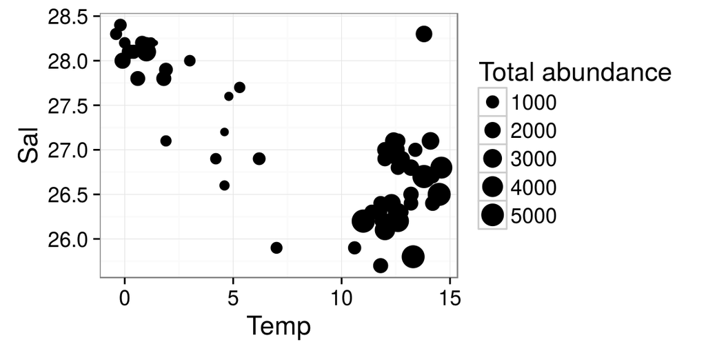

```r
library(ggplot2)
tot_abund <- apply(abund[, -1], 1, FUN = sum)
theme_set(theme_bw(base_size = 16))
ggplot(hydrol, aes(x = Temp, y = Sal, size = tot_abund)) + geom_point() +
    labs(size = "Total abundance")
```

## Висконсинская полярная ординация

Это простейший прием непрямой ординации

Шаг 1. Подготовим данные для анализа.

```r
log_abund <- log(abund[, -1] + 1)
row.names(log_abund) <- abund$Station
```

## Висконсинская полярная ординация

Шаг 2. Вычисление матрицы сходства/различия между объектами.  
Из дидактических соображений возьмем матрицу Евклидовых расстояний.

```r
library(vegan)
E_dist <- vegdist(log_abund, method = "euclidean")
# E_dist
```

## Висконсинская полярная ординация

Шаг 3. Найдем наиболее различающиеся объекты (максимальное Евклидово расстояние между ними).

```r
dist <- unfolding(log_abund)  # Пользовательская функция

dist[dist$Distance == max(dist$Distance), ]
```

```
##     i Object_j Object_k Distance
## 44 44        1       45     22.7
```

Эти два объекта и задают ось, вдоль которой будет производиться ординация.

## Висконсинская полярная ординация

Шаг 4. Координаты каждого из объектов на этой оси могут быть найдены, согласно правилам треугольника

Возьмем любую другую точку, например "S2"

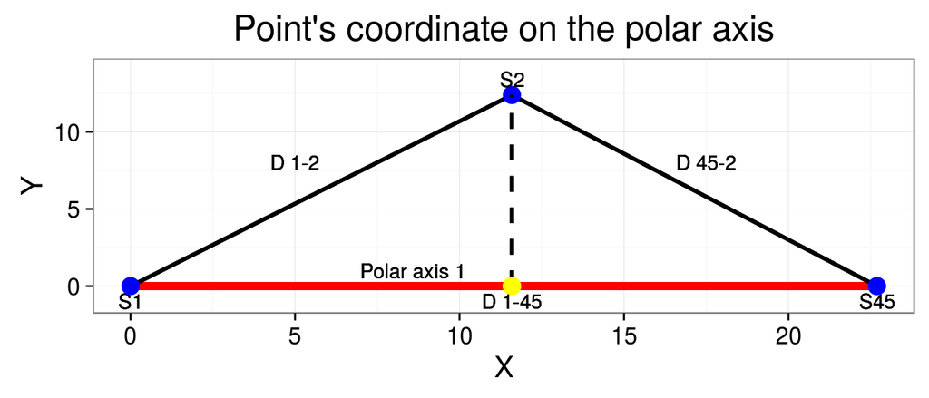

## Висконсинская полярная ординация

Шаг 5. Вычисляем координаты на полярной оси для каждого объекта.

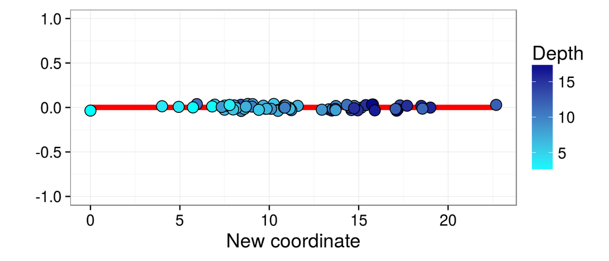

## Висконсинская полярная ординация

Шаг 6. При необходимости, находим следующую пару наиболее несходных объектов и вычисляем координаты для каждой точки на новой оси.

*At!* Одновременное изображение информации об обеих полярных осях на одной диаграмме невозможно!  
Мы не знаем как взаимосвязаны эти оси. Они могут быть неортогональны.

## Неметрическое многомерное шкалирование

### Non-metric multidimensional scaling (nMDS)

## Результаты функции `metaMDS()`

```r
library(vegan)
ord <- metaMDS(log_abund, distance = "bray", k = 2)  # результаты сохраняются в объекте ord
```

```
## ... procrustes: rmse 0.0204  max resid 0.154
## ... procrustes: rmse 0.000733  max resid 0.00454
## *** Solution reached
```

```r
ord
```

```
##
## Call:
## metaMDS(comm = log_abund, distance = "bray", k = 2)
##
## global Multidimensional Scaling using monoMDS
##
## Data:     log_abund
## Distance: bray
##
## Dimensions: 2
## Stress:     0.159
## Stress type 1, weak ties
## Two convergent solutions found after 2 tries
## Scaling: centring, PC rotation, halfchange scaling
## Species: expanded scores based on 'log_abund'
```

## Графическое представление результатов средствами пакета `vegan`

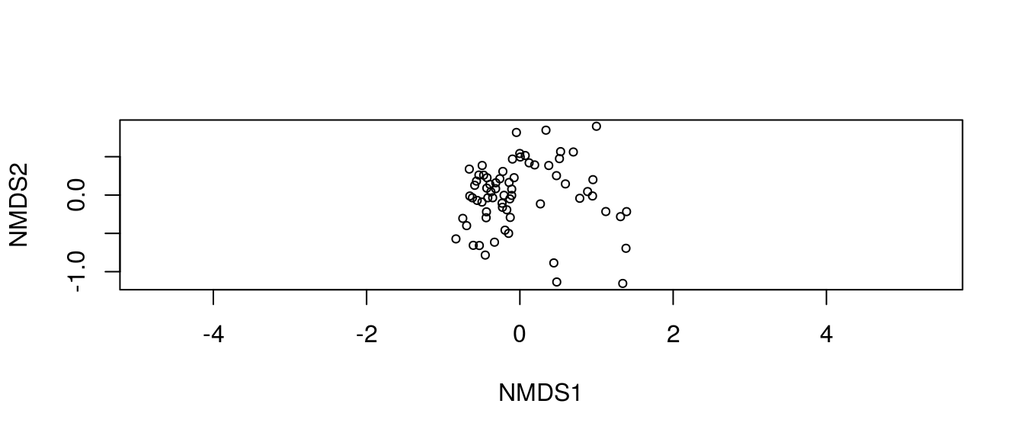

```r
ordiplot(ord, display = "sites")
```

```r
# text(ord) #Можно добавить обозначения сайтов (объектов)
```

## Задание: Графическое представление результатов средствами `ggplot2`

- Исследуйте объект `ord` и извлеките из него данные с новыми координатами
- Постройте график ординации при помощи пакета `ggplot2`
- Раскрасьте точки на ординации согласно глубине (данные в `hydrol`)

## Решение

Рассчитанные при помощи nMDS координаты объектов хранятся в элементе `points`

```r
ord$points
```

```
##         MDS1     MDS2
## S1  -0.83420 -0.57207
## S2   0.48112 -1.13413
## S3   0.94786 -0.01230
## S4  -0.09679  0.46923
## S5  -0.58905  0.12674
## S6  -0.37761  0.04179
## S7   0.88395  0.04522
## S8   0.12070  0.42002
## S9  -0.42854  0.22542
## S10 -0.43173  0.09027
## S12  1.38447 -0.69470
## S13  0.53139  0.56658
## S15 -0.13098 -0.05002
## S16  1.34239 -1.15332
## S17 -0.10662  0.07705
## S18 -0.10700 -0.00532
## S19 -0.31646  0.08287
## S20 -0.22212  0.30756
## S21  0.34038  0.84611
## S22  0.47755  0.25292
## S23 -0.47277  0.25892
## S24  0.99915  0.89695
## S25  0.37689  0.38526
## S26 -0.04523  0.81627
## S27 -0.17079 -0.19234
## S28 -0.20663 -0.00368
## S29 -0.14067  0.16391
## S30 -0.07538  0.22628
## S31  0.78149 -0.04244
## S32  0.51623  0.47470
## S33  1.31305 -0.28172
## S34  0.59417  0.14504
## S35  0.00506  0.49619
## S36 -0.31431  0.15947
## S37  1.39209 -0.21630
## S38  1.12128 -0.21537
## S39 -0.00148  0.54209
## S40  0.19307  0.39280
## S41 -0.26170  0.21225
```

[output cut: 20 more lines]

```
## S62 -0.74499 -0.30455
## S63 -0.12565 -0.29219
## S64 -0.22751 -0.15986
## S65 -0.43598 -0.21906
## S66 -0.65997  0.33841
## S67 -0.14698 -0.49997
## S68 -0.19402 -0.45834
## S69  0.26794 -0.11565
## S70 -0.52884 -0.65845
## attr(,"centre")
## [1] TRUE
## attr(,"pc")
## [1] TRUE
## attr(,"halfchange")
## [1] TRUE
```

## Решение

Координаты легко использовать для графика после преобразования в датафрейм.

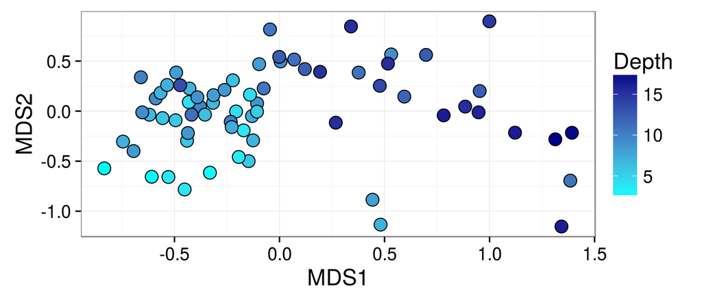

```r
ord_MDS <- data.frame(ord$points)

ggplot(ord_MDS, aes(x = MDS1, y = MDS2)) + geom_point(aes(fill = hydrol$Depth),
    size = 4, shape = 21) + scale_fill_gradient(low = "cyan", high = "darkblue") +
    labs(fill = "Depth")
```

## Важные свойства MDS

1. Ординация **сохраняет ранг расстояний между объектами** (похожие располагаются близко, непохожие — далеко; если объект А похож на B, больше чем на C, то и на ординации он окажется ближе к B, чем к C).
2. Значения координат точек в ординации лишены смысла (их вообще можно не приводить на итоговой ординации), имеет смысл лишь взаиморасположение объектов.
3. Облако точек в осях MDS можно вращать, перемещать, зеркально отражать. Суть ординации от этого не изменится.

## Решение

```r
obj <- c("S17", "S33", "S37", "S38", "S44", "S59")
red_abund <- log_abund[abund$Station %in% obj, ]
row.names(red_abund) <- obj
ord1 <- metaMDS(red_abund, distance = "bray")
```

[output not shown]

## Решение

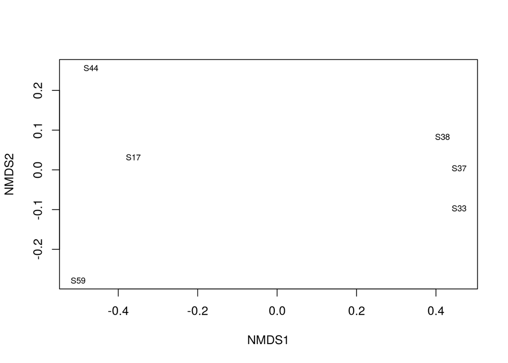

```r
ordiplot(ord1, display = "sites", type = "text")
```

## Решение

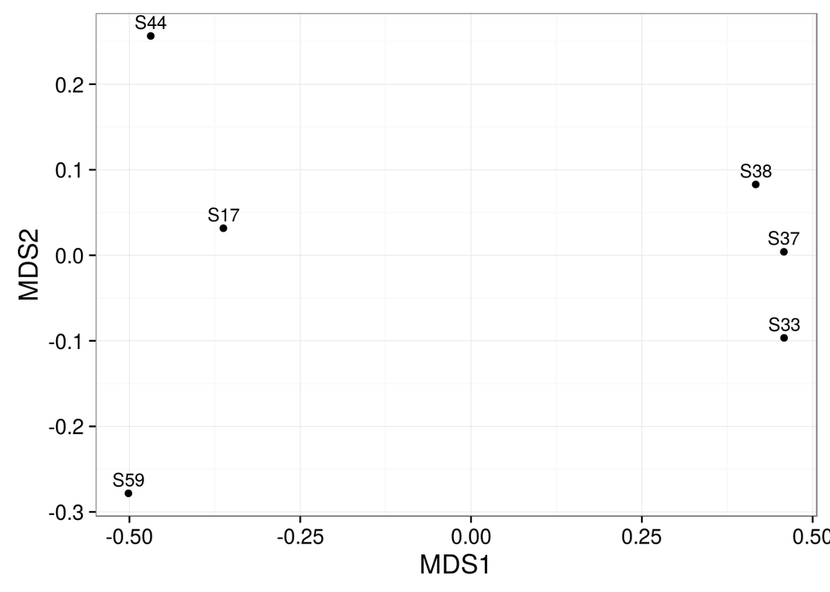

```r
ggplot(data.frame(ord1$points), aes(x = MDS1, y = MDS2)) + geom_point() +
    geom_text(aes(label = row.names(ord1$points)), vjust = -0.5)
```

```r
vegdist(red_abund[])
```

```
##       S17   S33   S37   S38   S44
## S33 0.875
## S37 0.868 0.145
## S38 0.792 0.224 0.142
## S44 0.402 1.000 1.000 0.905
## S59 0.425 1.000 1.000 1.000 0.543
```

## Взаиморасположение точек на плоскости подобно взаиморасположению точек в многомерном пространстве признаков

- В этом легко убедиться, построив график. Но мы видим, что расстояния не полностью совпадают

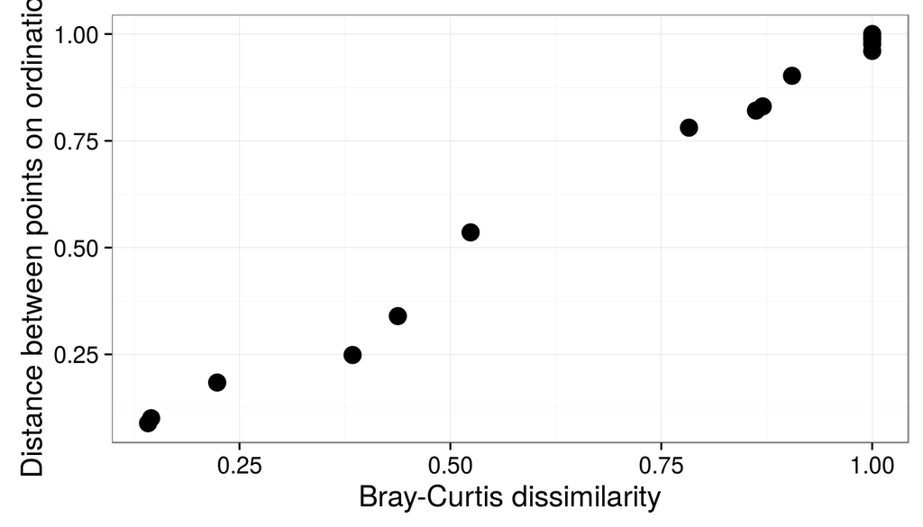

## Диаграмма Шепарда

**Диаграмма Шепарда** показывает соответствие расстояний на ординации и расстояний в исходном многомерном пространстве.

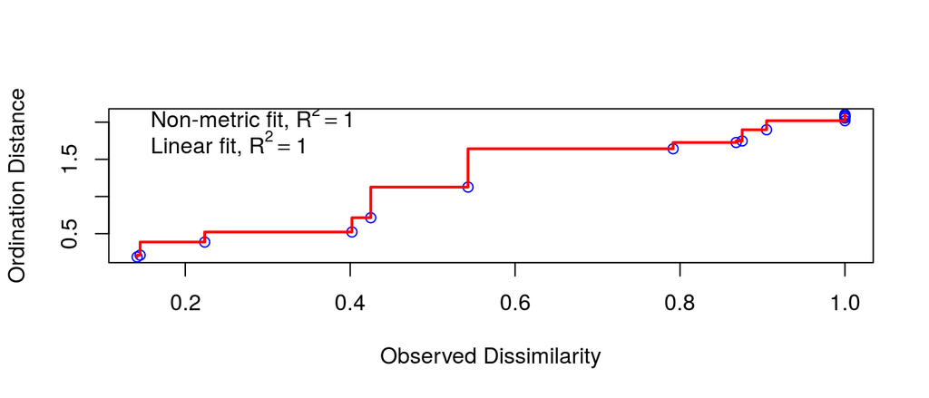

```r
stressplot(ord1)
```

- По оси X - откладываются ранжированные (расположенные в порядке возрастания) значения D (коэффициент Брея-Куртиса)
- По оси Y- соответствующие им, значения расстояний на плоскости – Z
- Ломаная линия на диаграмме - это монотонная регрессия.

## Монотонная регрессия

**Монотонная регрессия** минимизирует сумму квадратов отклонений значений координат на ординации от значений в исходном многомерном пространстве.

При одном условии: так, чтобы при этом сохранялись монотонные отношения между ними (если возрастает расстояние в исходном пространстве, то и на ординации оно должно возрастать). Именно это свойство монотонной регрессии позволяет сохранить ранги расстояний при построении ординации.

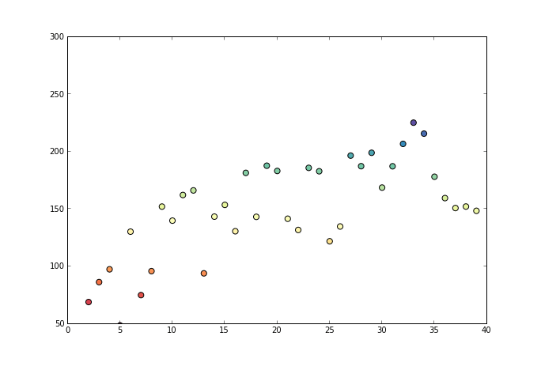

Иллюстрация из блога Fabian Pedregosa [о монотонной регрессии](http://fa.bianp.net/blog/tag/scikit-learn.html)

## Stress

**Stress** — мера соответствия ординации на плоскости взаиморасположению точек в многомерном пространстве признаков

\[ Stress = \sqrt{\frac{\sum{(Z_i - Zh_i)^2}}{\sum{Z_{i}^2}}}\]

Для вычисления величины стресса необходимо построить диаграмму Шепарда и подобрать монотонную регресию

## Посмотрим, что означает Stress.

Чтобы лучше представить себе, откуда берется стресс, оценим его величину для случайно выбранного расположения объектов по сравнению с нашей лучшей ординацией.

Создадим случайную ординацию для этого примера: передвинем все шесть точек на случайное расстояние.

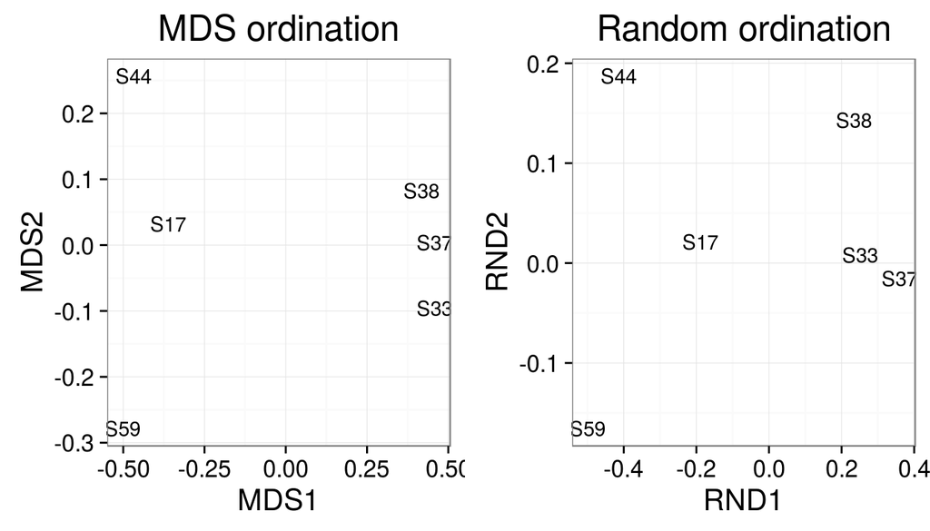

## Построение монотонной регрессии

Выпишем в развернутом виде матрицу коэффициентов Брея-Куртиса между точками на ординации, а так же между случайно расположенными точками. Отсортируем их в порядке возрастания расстояния на ординации.

```
##     i Object_j Object_k Distance RND_Distance
## 10 10        3        4    0.142        0.202
## 6   6        2        3    0.145        0.111
## 7   7        2        4    0.224        0.136
## 4   4        1        5    0.384        0.281
## 5   5        1        6    0.438        0.362
## 15 15        5        6    0.524        0.362
## 3   3        1        4    0.783        0.440
## 2   2        1        3    0.862        0.550
## 1   1        1        2    0.870        0.440
## 13 13        4        5    0.905        0.651
## 8   8        2        5    1.000        0.690
## 9   9        2        6    1.000        0.770
## 11 11        3        5    1.000        0.801
## 12 12        3        6    1.000        0.872
## 14 14        4        6    1.000        0.796
```

## Построение монотонной регрессии

Вычисляем последовательно средние значения так, чтобы каждое новое было не меньше предыдущего.

В R это делается при помощи функции `isoreg()`

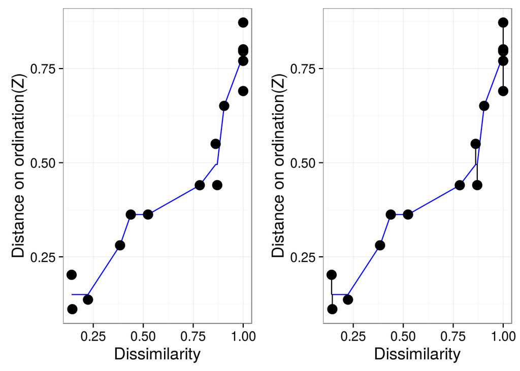

## Вычисление величины стресса

\[ Stress = \sqrt{\frac{\sum{(Z_i - Zh_i)^2}}{\sum{Z_{i}^2}}}\]

Для данной, случайной, ординации точек Stress = 0.077

## Алгоритм MDS

1. Вычисляем матрицу коэффициенттов различия между объектами.
2. Распределеяем объекты в случайном порядке на плоскости [NB! от первичного распределения точек может зависеть и результат, поэтому на практике используются процедуры оптимального начального размещения точек (PCA)].
3. Вычисляем значение стресса.
4. Двигаем точки по плоскости так, чтобы найти минимальное значение стресса.
5. Повторяем процедуру 2-4 несколько раз для того чтобы избежать локальных минимумов стресса.
6. Обычно финальную ординацию поворачивают вдоль оси X так, чтобы ось отражала максимальное варьирование.

[figure not shown]

## Задание:

Постройте диаграмму Шепарда вместе с монотонной регрессией на полном материале по Долгой губе. Найдите величину стресса.

Hint: Используйте функцию `stressplot()`

## Решение

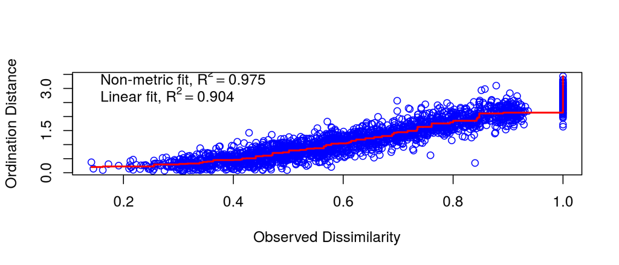

```r
stressplot(ord)
```

Stress = 0.159

Надежна ли такая ординация?

## Оценка качества подгонки

- Stress < 0.05 Ординация отличная. Можно в деталях проанализировать взаиморасположение точек
- 0.05 < Stress < 0.1 Хорошая конфигурация.
- 0.1 < Stress < 0.2 Приемлемая конфигурация. Надо быть осторожными в интерпретации.
- Stress > 0.2 Возможно, надо проводить ординацию в большем количестве осей. Двумерное изображение неадекватно отражает взаиморасположение точек.

## MDS в трехмерном пространстве

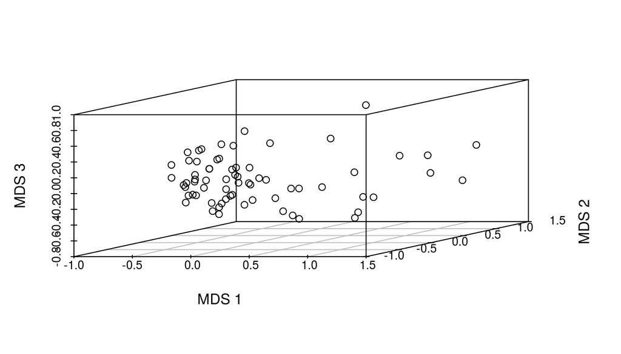

Stress = 0.127

At! Ни в коем случае не используете координаты 3D MDS для двумерной ординации.

## Сравнение ординаций

## Задание:

- Постройте ординацию всех станций с использованием Евклидова расстояния

## Решение

```r
ord4 <- metaMDS(log_abund, distance = "euclidean")
```

```
## ... procrustes: rmse 0.00143  max resid 0.00676
## *** Solution reached
```

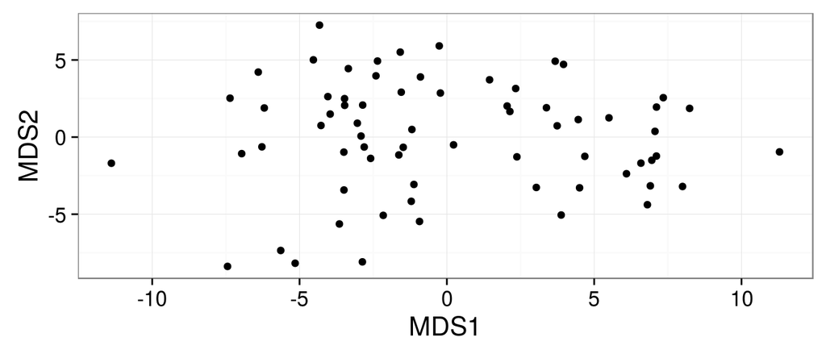

```r
ggplot(data.frame(ord4$points), aes(x = MDS1, y = MDS2)) + geom_point()
```

## Насколько похожи ординации, полученные при использовании коэффициента Брея-Куртиса и Евклидова расстояния?

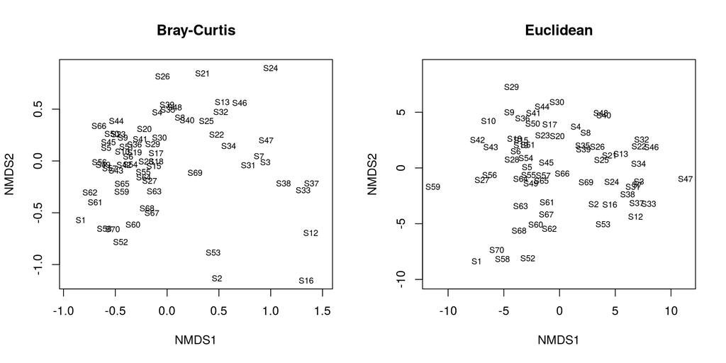

## Прокурстово преобразование

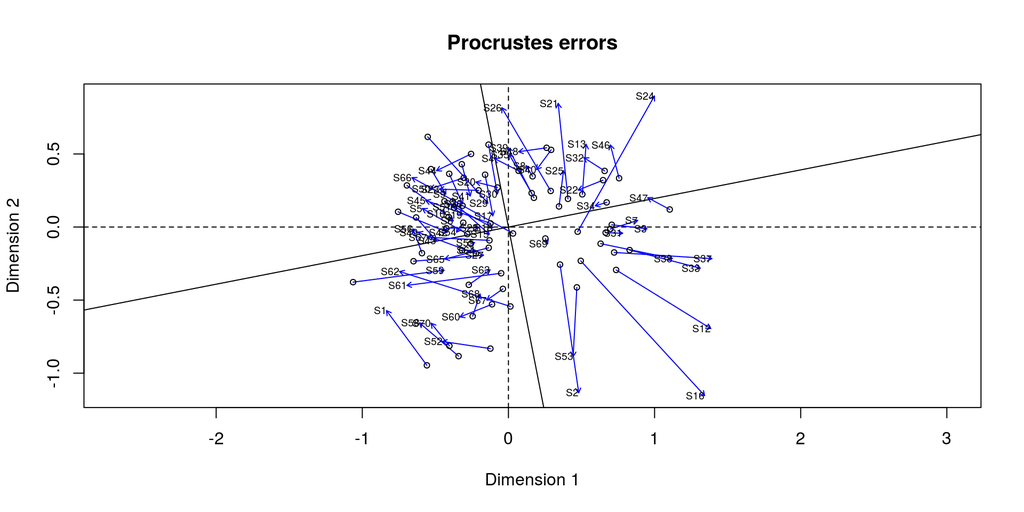

```r
procrust <- procrustes(ord, ord4)
plot(procrust)
text(procrust, adj = 1, cex = 0.6)
```

## Трактовка результатов ординации

## Трактовка результатов ординации

О более изощренных способах — на следующей лекции

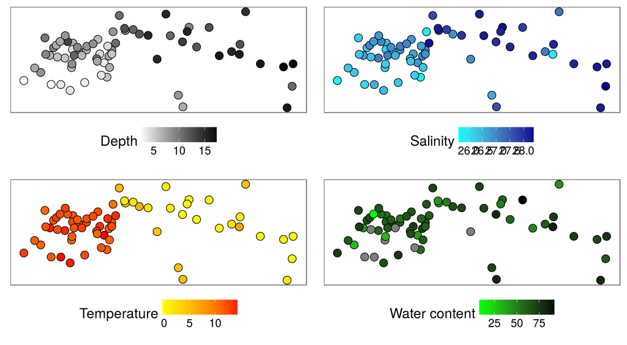

## Take-home messages

- Существует много методов непрямой ординации.
- nMDS - один из методов ординации в пространстве сниженной размерности. При ординации этим методом сохраняются ранги расстояний между объектами.
- Оценка качества подгонки ординации производится с помощью величины стресса.
- Значения координат не имеют особенного смысла. Имеет значение только взаиморасположение точек.
- Результат nMDS зависит от выбора меры различия

## Литература

- Borcard, D., Gillet, F., Legendre, P., 2011. Numerical ecology with R. Springer.
- Legendre, P., Legendre, L., 2012. Numerical ecology. Elsevier.
- Oksanen, J., 2011. Multivariate analysis of ecological communities in R: vegan tutorial. R package version 2–0.
- Zuur, A. F., Ieno, E. N., Smith, G. M. Analysing Ecological Data. Springer 2007
- Миркин Б.М., Розенберг Г.С., Наумова Л.Г. Словарь понятий и терминов современной фитоцентологии. М. Наука, 1989.